# Invariant Coordinate Selection (ICS) - Julia tutorial

ICS and Related Methods Conference 26-28 May 2026, Helsinki, Finland

Valentin Todorov

valentin@todorov.at

May 28, 2026

## Introduction

Invariant Coordinate Selection (ICS) is an unsupervised multivariate statistical method used for dimension reduction, outlier detection, and cluster identification. By simultaneously diagonalizing two different scatter matrices, ICS projects high-dimensional data into a new, meaningful coordinate system to easily uncover underlying structures. It is particularly useful for dimension reduction. Unlike PCA, ICS is not based on variance maximization but on the maximization/minimization of a generalized kurtosis, and it is invariant not only to orthogonal data transformations but also to any affine transformation.

The `Julia` `ICSTools` package brings the main functionalities of the `R` `ICS` package to `Julia`, offering tools for identifying and selecting invariant coordinates in multivariate data. It includes various covariance estimators, transformation settings, and plotting utilities. Our extensive testing ensures results consistent with the `R` package, making it easy for users to transition from `R` to `Julia` or start fresh with `ICS`.

The source code of the `Julia` package `ICSTools` is available at our GitHub Repository: [ICSTools](https://github.com/valentint/ICSTools.jl).

The complete documentation of the API with examples can be found at [`ICSTools` Documentation](https://valentint.github.io/ICSTools.jl/dev/).

The results of the test coverage are available at [`ICSTools` Tests](https://app.codecov.io/github/valentint/ICSTools.jl?branch=main).

To run the code from this tutorial you will need to install `Julia`. The recommended way of installing `Julia` is based on `juliaup` which (on Windows) can be found [here](https://apps.microsoft.com/detail/9njnww8pvkmn?hl=fi-FI&gl=FI). Further you will need an IDE for more comfortable running of the code - the preferred one is [VSCode](https://code.visualstudio.com/) with installed `Julia` plugin which can be obtained from [here](https://marketplace.visualstudio.com/items?itemName=julialang.language-julia).

The `R Markdown` file of the tutorial could be run in `RStudio` but you will need also `R` installed.

In [this GitHub repository](https://github.com/AuroreAA/ICS-implementation) is available also a [Pluto](https://plutojl.org/) [notebook](https://github.com/AuroreAA/ICS-implementation/blob/main/Julia/ICS.Pluto) containing a part of the tutorial.

All the code chunks of the repository are extracted into a [`Julia` script](https://github.com/AuroreAA/ICS-implementation/blob/main/Julia/Julia_ICS_tutorial.jl).

```julia
import Pkg;
Pkg.add("Robustbase"); using robustbase # for MCD
Pkg.add("ICSTools"); using ICSTools
Pkg.add("Plots"); using Plots
Pkg.add("DataFrames"); using DataFrames
Pkg.add("GLMakie"); using GLMakie       # for pairplots() and related
Pkg.add("PairPlots"); using PairPlots   # for pairplots() and related
Pkg.add("RCall"); using RCall           # To access R data sets; to perform tests
Pkg.add("Clustering"); using Clustering # for kmeans() and randindex()
Pkg.add("Test"); using Testing          # for testing against R
Pkg.add("BenchmarkTools"); using BenchmarkTools # for benchmarking scatter functions
Pkg.add("Random");Random                # for testing and benchmarking
```

## Getting started

```julia
using ICSTools

# Load dataset
using Robustbase
X=wood[:,1:5];
```

```julia
## Instantiate ICSModel object with all default parameters
ics = ICSModel();
show(ics)
```

```
##
## ICS based on two scatter matrices
## S1: cov2
## S1_args: Dict{Symbol, Any}()
## S2: covW
## S2_args: Dict{Symbol, Any}()
##
## Information on the algorithm:
## algorithm: whiten
## center: false
## fix_signs: scores
##
## Model is not fitted yet!
```

```julia
## Alternative instantiations:

## 1. With values for S1 and S2
ics1 = ICSModel(S1=cov2, S2=cov4);

## 2. With arguments for S2
ics2 = ICSModel(S1=cov2, S2=covW, S2_args=Dict{Symbol, Any}(:alpha=>1, :cf=>2));

## 3. With algorithm
ics3 = ICSModel(S1=cov2, S2=covW, algorithm="standard");
```

With the function `fit_predict!()` we will fit the ICS model and transform the data - equivalent to the function `ICS-S3()` from the `R` package `ICS`. Alternatively, this can be done in two separate steps: `fit!()` and `predict!()`, as is usually done in machine learning pipelines.

```julia
scores = fit_predict!(ics, X);
show(ics)
```

```
##
## ICS based on two scatter matrices
## S1: cov2
## S1_args: Dict{Symbol, Any}()
## S2: covW
## S2_args: Dict{Symbol, Any}()
##
## Information on the algorithm:
## algorithm: whiten
## center: false
## fix_signs: scores
##
## The generalized kurtosis measures of the components are:
## IC_1: 6.6248
## IC_2: 6.1884
## IC_3: 5.2813
## IC_4: 4.8105
## IC_5: 3.9477
##
## The coefficient matrix of the linear transformation is:
##                x1           x2           x3           x4           x5
## IC_1        1.19971    -31.83104      2.33736    -18.83172     -5.98021
## IC_2      -19.90580     58.80711      7.75780     19.47824    -28.44422
## IC_3        5.15339     11.03716     13.29070     -4.88970      5.98969
## IC_4       -2.44957    -43.70081     12.92686     -9.08586     21.63247
## IC_5       -4.00962     35.25209     -0.55332     -2.70552     -1.55875
```

```julia
scores
```

```
## 20×5 Matrix{Float64}:
##  -16.7574  -15.0133  12.7086  13.2842  -1.58809
##  -17.8712  -15.5105  14.5037  13.5282  -0.9788
##  -17.4835  -16.7649  14.0566  14.5065  -1.05921
##  -17.3958  -15.86    13.8091  15.3582   0.918907
##  -16.961   -16.0117  14.0718  15.6424  -1.31639
##  -17.2711  -15.9198  13.6709  14.8956   1.07561
##  -15.5143  -12.7103  14.0587  14.3786  -0.447561
##  -17.7991  -14.5827  13.2857  14.3302   1.32258
##  -15.5807  -14.3794  14.7813  15.4326  -0.89646
##  -18.7687  -14.5552  16.3595  14.2917  -0.53292
##  -17.3183  -15.2455  14.7408  12.3598   0.00287171
##  -16.1634  -15.786   14.4912  12.3209  -0.97496
##  -17.3042  -15.2093  16.0166  14.9641  -0.841011
##  -17.6189  -15.4777  13.5234  14.3221  -1.61633
##  -17.8304  -14.0505  13.4756  14.4841  -1.32798
##  -19.4147  -12.9501  13.376   13.7981  -0.811453
##  -19.1585  -15.2576  14.3655  15.2923  -1.35671
##  -17.0606  -14.5333  13.2685  16.1647  -1.33691
##  -17.6047  -15.0584  13.2403  14.2924   1.399
##  -17.8348  -15.8362  12.1999  14.0898  -1.57377
```

The following example illustrates how to plot the transformed/predicted data (invariant components) using `component_plot2()` and the kurtosis of the invariant components (corresponding to the eigenvalues of the joint diagonalization problem) using `scree_plot()`.

```julia
## scree plot and 2-dimensional component plot
using Plots
gr()
```

```
## Plots.GRBackend()
```

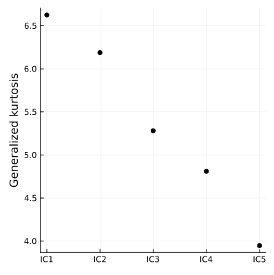

```julia
scree_plot(ics)
```

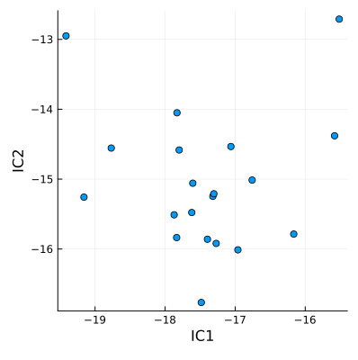

```julia
component_plot2(ics)                # by default the first two components
```

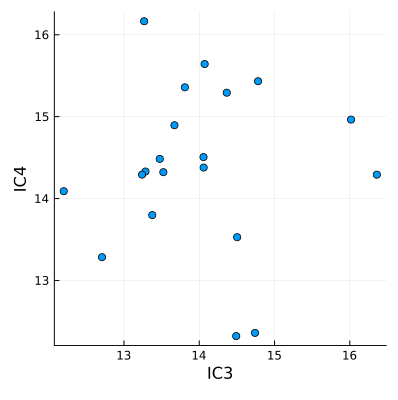

```julia
component_plot2(ics, select=[3,4])  # select components 3 and 4
```

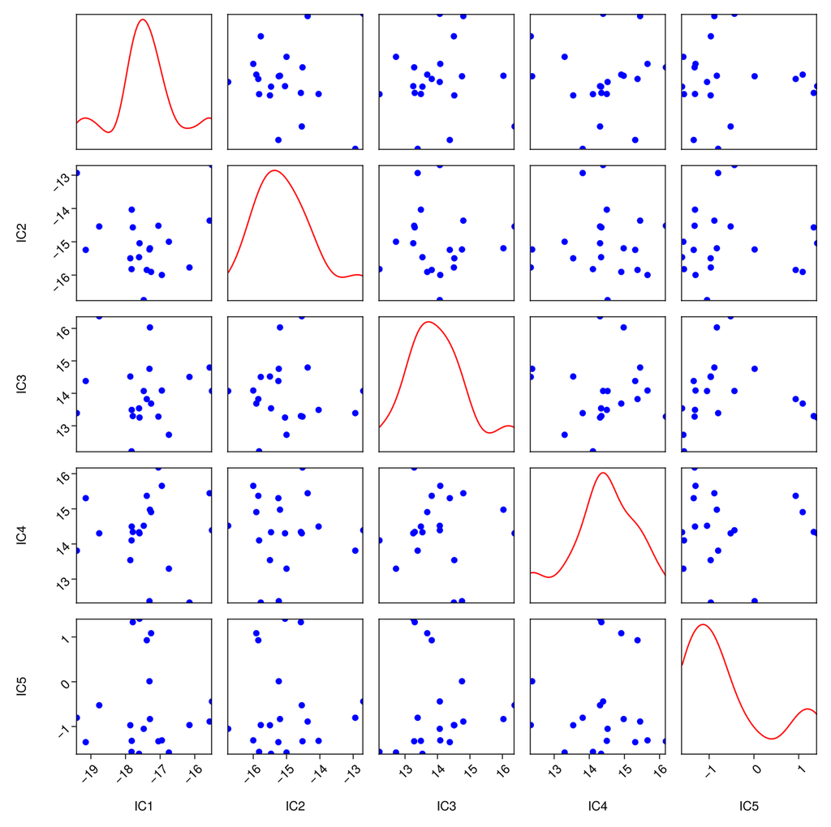

```julia
using DataFrames
using GLMakie
using PairPlots
ss = DataFrame(scores, ["IC$i" for i=1:size(scores,2)]);
fig = pairplot(ss, fullgrid=true);

fig = pairplot(
    ss => (PairPlots.Scatter(markersize=10, color=:blue),
          PairPlots.MarginDensity(color=:red)),
          fullgrid=true
)

save("images/wood-scores.png", fig)
```

## The scatters

ICS is based on simultaneously diagonalizing two different scatter matrices. The ICSTools package contains a number of implementations of scatter matrices, almost all scatters that are available in the different packages in `R`. Each scatter function takes a data matrix or a data frame and returns a structure with the following fields:

- (optional) location
- scatter matrix
- label

```julia
using ICSTools

# Load dataset
using Robustbase
X=wood[:,1:5];

cov4(X)
```

```
## -> Scatter: COV4
## Location:
## [0.55085, 0.13304, 0.50865, 0.5112, 0.90695]
##
## Scatter:
## 5×5 Matrix{Float64}:
##   0.00571919  -4.00121e-5    0.00240916    0.00157329   -0.00172161
##  -4.00121e-5   0.000296558  -0.000155744  -0.000411835   0.000377114
##   0.00240916  -0.000155744   0.00302313    0.000877546  -0.00117088
##   0.00157329  -0.000411835   0.000877546   0.00274575   -0.000104867
##  -0.00172161   0.000377114  -0.00117088   -0.000104867   0.0020241
```

Some scatter functions can take optional arguments. All functions are implemented in the `ICSTools` package, `mcd_raw()` and `mcd_rew()` use the Julia package `Robustbase` for the implementation of the FASTMCD algorithm.

```julia
covW(X, alpha=2, cf=4)
```

```
## -> Scatter: COVW
## Location:
## [0.55085, 0.13304, 0.50865, 0.5112, 0.90695]
##
## Scatter:
## 5×5 Matrix{Float64}:
##   0.90569     0.0204782    0.352329     0.210905   -0.211631
##   0.0204782   0.0402795   -0.00954821  -0.0386719   0.0530409
##   0.352329   -0.00954821   0.484683     0.0984048  -0.186089
##   0.210905   -0.0386719    0.0984048    0.463618    0.0586492
##  -0.211631    0.0530409   -0.186089     0.0586492   0.341285
```

When scatter functions are used as arguments to `ICSModel()`, the optional arguments can be passed as data dictionaries:

```julia
ics1 = ICSModel(S1=cov2, S2=covW, S2_args=Dict{Symbol, Any}(:alpha=>2, :cf=>4));

ics2 = ICSModel(S1=mcd_raw, S2=cov2, S1_args=Dict{Symbol, Any}(:nsamp=>1000, :alpha=>0.75));
```

Table 1. List of scatter functions implemented in the `Julia`package `ICSTool`.

|  | Function | Location | Optional parameters |
| --- | --- | --- | --- |
| Covariance | `cov2` | Yes | - |
| Fourth-moment covariance | `cov4` | Yes | - |
| One-step M-estimator | `covW` | Yes | `alpha`, `cf` |
| One-step Tyler shape matrix | `covAxis` | Yes | - |
| Multivariate t-distribution estimator | `tM` | Yes | `alg`, `mu_init`, `V_init`, `gamma_init`, `eps`, `maxiter` |
| Cauchy location and scatter | `mlc` | Yes | `alg`, `mu_init`, `V_init`, `gamma_init`, `eps`, `maxiter` |
| Raw MCD | `mcd_raw` | Yes | `alpha`,`nsamp` |
| Reweighted MCD | `mcd_rwt` | Yes | `alpha`, `nsamp` |
| Pairwise one-step M-estimate | `tcov` | No | `beta` |
| Local shape scatter | `lcov` | No | `proportion`, `mscatter`, `mcdalpha`, `covstandard` |

### Testing against `R`

Since all scatter functions are also available in several different `R` Packages we can conveniently test the by running the `R` code comparing the results. An example is given below.

```julia
using DataFrames
using RCall
using Test

## Load R libraries
R"library(ICSOutlier)";
R"library(ICSClust)";

cc=R"ICS_cov4($X, location='mean')";    # call cov4() in R
ss=cov4(X);                             # call cov4() in Julia
```

```julia
## Compare the returned labels, locations and scatters
@test(ss.label == rcopy(cc)[Symbol("label")])
@test(isapprox(ss.location, rcopy(cc)[Symbol("location")]))
@test(isapprox(ss.scatter, rcopy(cc)[Symbol("scatter")]))
```

### Benchmarking

One of the main advantages of Julia`is the so called solving of the "two languages problem", i.e. in order to achive satifactury computational speed in`R`or`Python`it is necessary t program critical parts of the code in a native compiled languages like`C`or`C++`.This is not neessary in`Julia`` - everything is written in the same language. A good example for this is the scatter function `tcov()` which in `R` is written in `C++`. To illustrate this we will benchmark this functions.

```julia
using BenchmarkTools
using ICSTools
using Random

X = rand(1000, 10);

bb1 = @benchmark tcov(X) samples=19;
bb1
```

```
## BenchmarkTools.Trial: 19 samples with 1 evaluation per sample.
##  Range (min … max):  107.176 ms … 127.971 ms  ┊ GC (min … max): 0.00% … 0.00%
##  Time  (median):     117.777 ms               ┊ GC (median):    0.00%
##  Time  (mean ± σ):   117.176 ms ±   5.275 ms  ┊ GC (mean ± σ):  0.00% ± 0.00%
##
##   ▁     ▁  █       ▁       ▁ ▁ ▁▁█ ▁ ▁▁▁   ▁  ▁    ▁          ▁
##   █▁▁▁▁▁█▁▁█▁▁▁▁▁▁▁█▁▁▁▁▁▁▁█▁█▁███▁█▁███▁▁▁█▁▁█▁▁▁▁█▁▁▁▁▁▁▁▁▁▁█ ▁
##   107 ms           Histogram: frequency by time          128 ms <
##
##  Memory estimate: 161.86 KiB, allocs estimate: 28.
```

The following graph presents the timing of two versions of the function `tcov()` in `Julia`, the first is straightforward translation of the `C++` code in the `R` package `ICSClust`, the second is optimized for `Julia`.

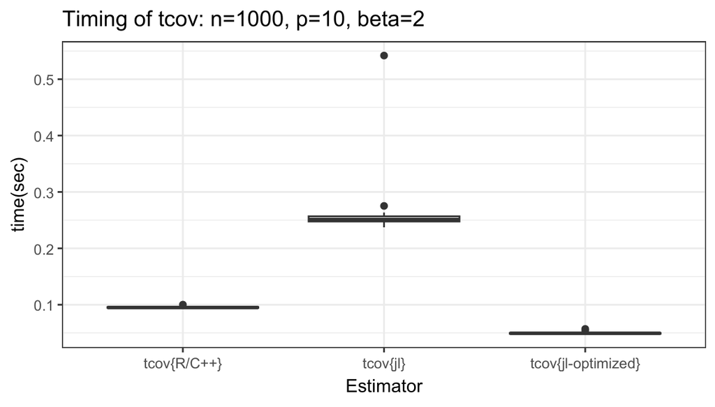

## Example applications

### The Penguins data set

Data on adult penguins covering three species found on three islands in the Palmer Archipelago, Antarctica, including their size (flipper length, body mass, bill dimensions), and sex. The data set `penguins` in `R` is a data frame with 344 rows and 8 variables. It is also available in `Julia` as a package `PalmerPenguins.jl`.

Be careful there are missing values so we could consider only 342 observations. However, there are further 9 observations for which the variable `sex` has `NA`, therefore it is better to work with the remaining 333 observations.

The idea of the penguins data set is to replace the well known `iris` data set which is used throughout data science, education statistical software and machine learning as test and illustration data set. The structure of `penguins` is similar to that of `iris` but still there are several essential differences: There are several grouping variables (species, island, sex and year), the sample sizes of the groups (152-68-124) are not equal as in iris (3x50), there are a few observations with missing values.

Table 1. Sample sizes for `iris` and `penguins`. Data in penguins can be further grouped by island and study year.

| Iris species | Sample size | Penguin species | Female | Male | NA |
| --- | --- | --- | --- | --- | --- |
| setosa | 50 | Adélie | 73 | 73 | 6 |
| versicolor | 50 | Chinstrap | 34 | 34 | 0 |
| virginica | 50 | Gentoo | 58 | 61 | 5 |

We start by downloading the data set from `R`:

```julia
## Load the penguins data from R
using DataFrames
using RCall
Robj = R"data('penguins', package='datasets'); x=penguins";

## Copy the contents of an R object into a corresponding canonical Julia type
penguins = rcopy(Robj);
size(penguins)
penguins = dropmissing(penguins); # drop the missing values
size(penguins)
X = penguins[:,3:6];              # select only the quantitative variables
```

```julia
## Tabulate species by sex
gdf = groupby(penguins, [:species, :sex]);
tt = combine(gdf, nrow);
show(IOContext(stdout, :limit=>false), MIME"text/plain"(), tt)
```

```
## 6×3 DataFrame
##  Row │ species    sex     nrow
##      │ Cat…       Cat…    Int64
## ─────┼──────────────────────────
##    1 │ Adelie     female     73
##    2 │ Adelie     male       73
##    3 │ Chinstrap  female     34
##    4 │ Chinstrap  male       34
##    5 │ Gentoo     female     58
##    6 │ Gentoo     male       61
```

Now we apply ICS with scaters `tcov` and `cov2`, transform the model using the penguin data and plot the `scree_plot` (analogue to eigenvalues screeplot in PCA).

```julia
using ICSTools
ics = ICSModel(S1=tcov, S2=cov2);
scores = fit_predict!(ics, X);
```

```julia
using Plots
gr()
```

```
## Plots.GRBackend()
```

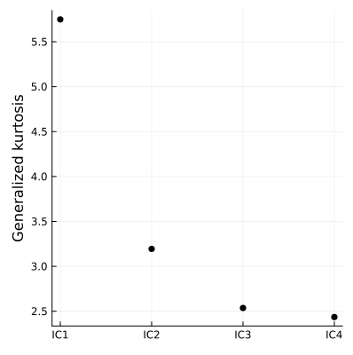

```julia
scree_plot(ics)
```

For convenience, to look at the data taking the grouping by species and by sex into account we convert the categorical arrays into string arrays.

```julia
## Convert the categorical arrays species and sex to string arrays
using CategoricalArrays
species = unwrap.(penguins.species);
sex = unwrap.(penguins.sex);
```

Then we plot the first two IC components grouping the data by species (the different colours represent the different species). We see that the species are very well separated.

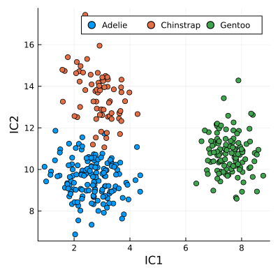

```julia
## Convert the categorical arrays species and sex to string arrays
component_plot2(ics, clusters=species)
```

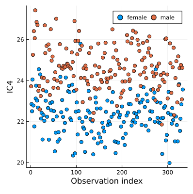

```julia
## Convert the categorical arrays species and sex to string arrays
component_plot2(ics, clusters=sex, select=[4])
```

Finally, we look at the pair plots of the IC scores of the penguins data. This function (`component_plot()`) is not implemented in the `ICSTools` package, therefore we call directly the `pairplot()` function. The grouping is by species.

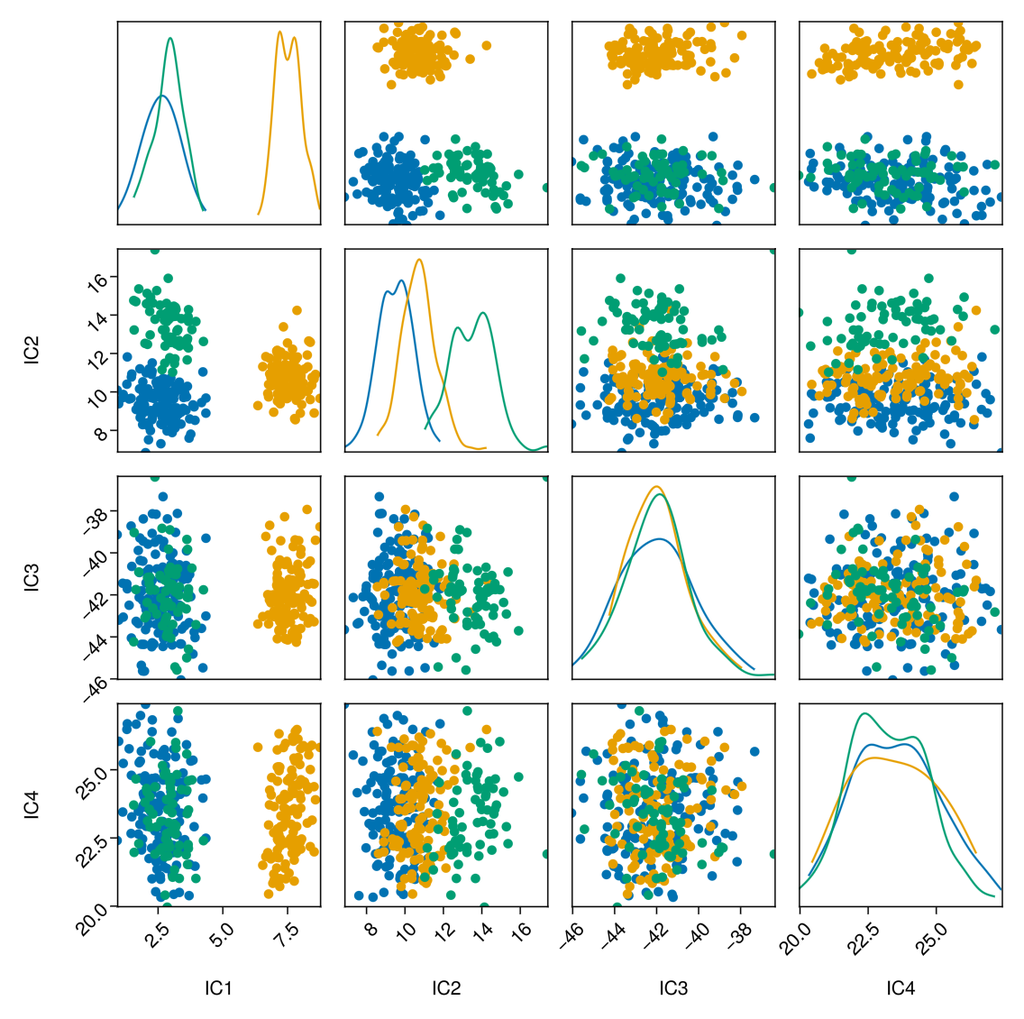

```julia
using DataFrames
using GLMakie
using PairPlots

ss = DataFrame(scores, ["IC$i" for i=1:size(scores,2)]);

fig=pairplot(ss[species .== "Adelie", :] =>
             (PairPlots.Scatter(markersize=10),
              PairPlots.MarginDensity()),
            ss[species .== "Gentoo", :] =>
             (PairPlots.Scatter(markersize=10),
              PairPlots.MarginDensity()),
            ss[species .== "Chinstrap", :] =>
             (PairPlots.Scatter(markersize=10),
              PairPlots.MarginDensity()),
          fullgrid=true)
save("images/penguins-plot-species.png", fig)
```

Now we repeat the same with grouping by sex.

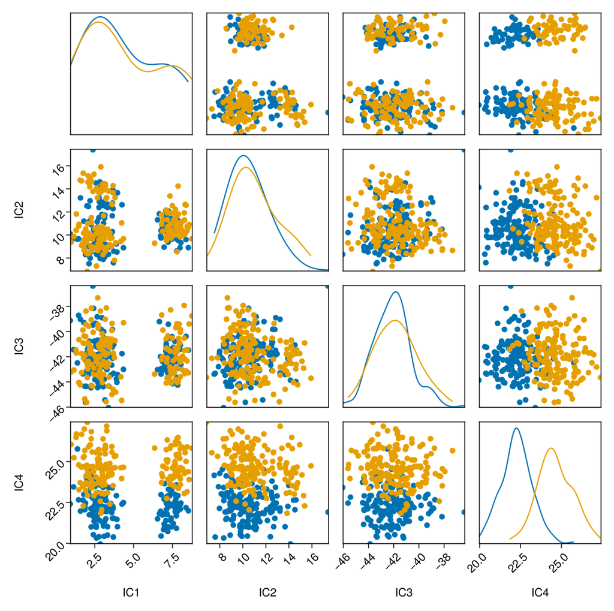

```julia
fig=pairplot(ss[sex .== "female", :] =>
             (PairPlots.Scatter(markersize=10),
              PairPlots.MarginDensity()),
            ss[sex .== "male", :] =>
             (PairPlots.Scatter(markersize=10),
              PairPlots.MarginDensity()),
          fullgrid=true)
save("images/penguins-plot-sex.png", fig)
```

### Cluster analysis

The Philips data set was first introduced in the robustness literature in Rousseeuw and Van Driessen (1999) as a motivation example for developing the FASTMCD algorithm. Later it was used as an example in a number of papers and presentations (Maronna and Zamar, 2002; Willems et al., 2009).

The data set is available in the `R` package `cellWise`. For each of `n = 677` parts (metal plates molded by a press) `p = 9` characteristics were measured. The aim of the multivariate analysis was to gain insight in the interrelations between the variables and to investigate if any deformations or abnormalities have occurred during the production process. There are two groups of outliers (as analyzed by the Philips engineers and demosntrated by Rousseeuw et al. (1999): the first 100 observations and the 75 observations with indexes 491 to 565. The thirsd group are the 502 regular observations.

We start by downloading the Philips data set from `R`:

```julia
## Load the penguins data from R
using DataFrames
using RCall
RObj = R"data('data_philips', package='cellWise'); x=data_philips";

## Copy the contents of an R object into a corresponding canonical Julia type
X = rcopy(RObj)
size(X)

## Define the clusters
clusters = repeat(["Group1"], outer=size(X, 1))
clusters[1:100] .= "Group2"
clusters[491:565] .= "Group3"

## We will use these to validate the k-means
true_labels = fill(1, size(X, 1))
true_labels[1:100] .= 2
true_labels[491:565] .= 3
```

Now we apply ICS with scaters `mcd_raw` and `cov2`, transform the model using the Philips data and plot the `scree_plot` (analogue to eigenvalues scree plot in PCA).

```julia
using ICSTools
ics = ICSModel(S1=mcd_raw, S2=cov2);
scores = fit_predict!(ics, X);

using Plots
gr()
```

```
## Plots.GRBackend()
```

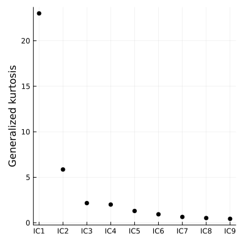

```julia
scree_plot(ics)
```

Show the clusters in the first two ICs

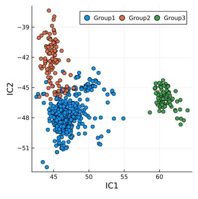

```julia
component_plot2(ics, clusters=clusters)
```

Show the pair plots of the first 3 and the last three ICs.

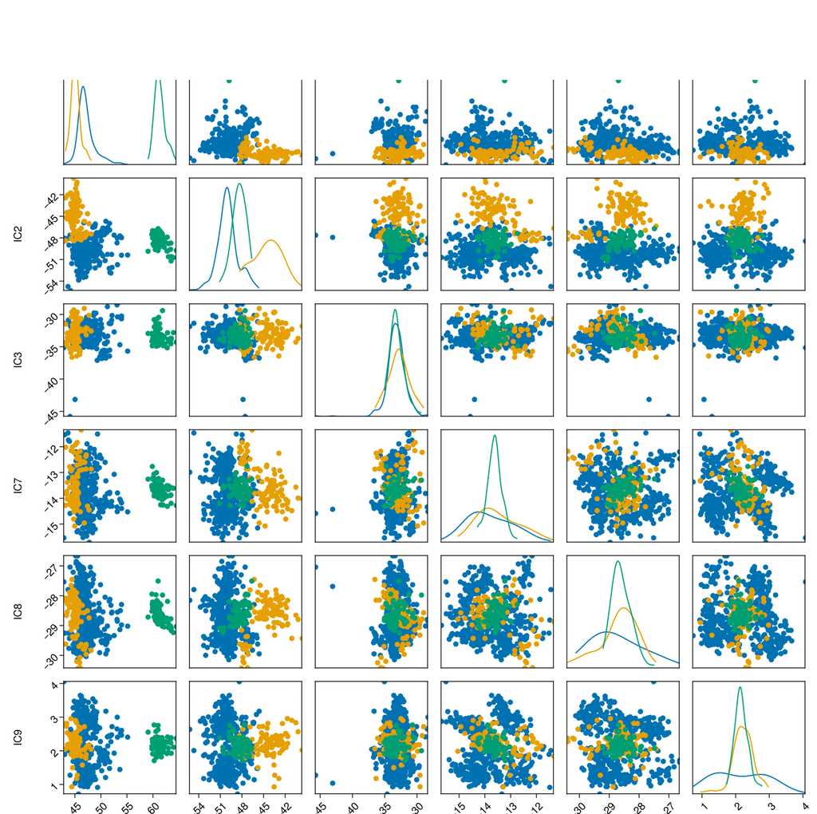

```julia
using DataFrames
using GLMakie
using PairPlots

ss = DataFrame(scores[:,[1, 2, 3, 7, 8, 9]], ["IC$i" for i=[1, 2, 3, 7, 8, 9]]);
ss_raw = DataFrame(X[:,[1, 2, 3, 7, 8, 9]], ["X$i" for i=[1, 2, 3, 7, 8, 9]]);

fig=pairplot(ss[clusters .== "Group1", :] =>
             (PairPlots.Scatter(markersize=10),
              PairPlots.MarginDensity()),
            ss[clusters .== "Group2", :] =>
             (PairPlots.Scatter(markersize=10),
              PairPlots.MarginDensity()),
            ss[clusters .== "Group3", :] =>
             (PairPlots.Scatter(markersize=10),
              PairPlots.MarginDensity()),
          fullgrid=true)
save("images/philips-pairs.png", fig)
```

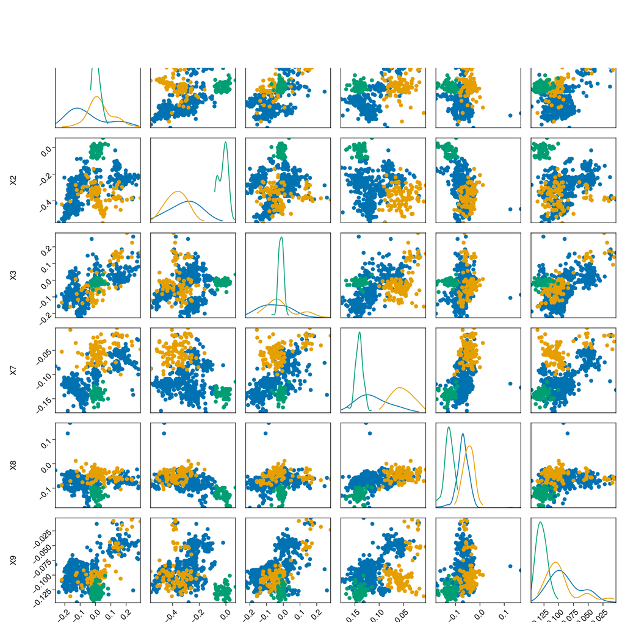

```julia
fig_raw=pairplot(ss_raw[clusters .== "Group1", :] =>
             (PairPlots.Scatter(markersize=10),
              PairPlots.MarginDensity()),
            ss_raw[clusters .== "Group2", :] =>
             (PairPlots.Scatter(markersize=10),
              PairPlots.MarginDensity()),
            ss_raw[clusters .== "Group3", :] =>
             (PairPlots.Scatter(markersize=10),
              PairPlots.MarginDensity()),
          fullgrid=true)
save("images/philips-raw.png", fig_raw)
```

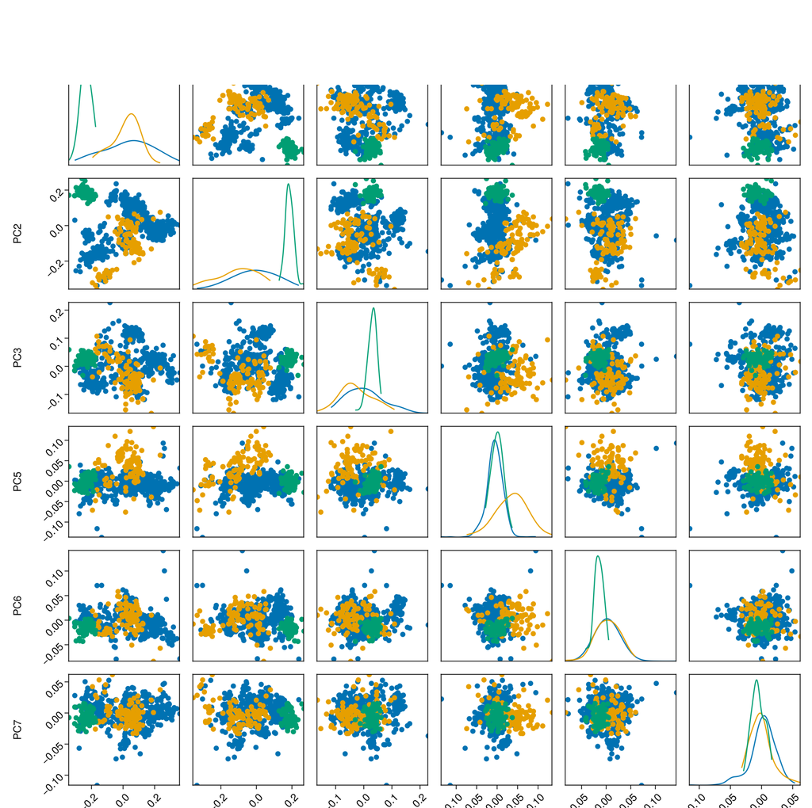

```julia
using MultivariateStats
Xtr=Matrix(X)'
M = fit(PCA, Xtr; maxoutdim=9)
Ytr = MultivariateStats.predict(M, Xtr)'
ss_pca = DataFrame(Ytr[:,[1, 2, 3, 5, 6, 7]], ["PC$i" for i=[1, 2, 3, 5, 6, 7]]);

fig_pca=pairplot(ss_pca[clusters .== "Group1", :] =>
             (PairPlots.Scatter(markersize=10),
              PairPlots.MarginDensity()),
            ss_pca[clusters .== "Group2", :] =>
             (PairPlots.Scatter(markersize=10),
              PairPlots.MarginDensity()),
            ss_pca[clusters .== "Group3", :] =>
             (PairPlots.Scatter(markersize=10),
              PairPlots.MarginDensity()),
          fullgrid=true)
save("images/philips-pairs_pca.png", fig_pca)
```

Now let us turn the exploratory observations on the three pair plots to more concrete numbers. We can run k-means clustering on the raw data, the (first 3) PCA scores and the (first 3) ICs. Since we know the true clusters, we can compute a suitable external validation measure like the Adjusted Rand index and compare them.

```julia
## 1. Do k-means on the raw data
using Clustering
result = kmeans(X', 3);
ri, ari_raw = randindex(result.assignments, true_labels);
ari_raw

## Do k-means on the first 3 ICs
using Clustering
Y=scores[:,1:3];
result_ICS = kmeans(Y', 3);
ri, ari_ICS = randindex(result_ICS.assignments, true_labels);
ari_ICS

##  Do k-means on the first 3 PCs
using MultivariateStats
using Clustering
Xtr=Matrix(X)';
M = fit(PCA, Xtr; maxoutdim=9);
Ytr = MultivariateStats.predict(M, Xtr)';
Ytr3 = Ytr[:,1:3]';
result_PCA = kmeans(Ytr3, 3);
ri, ari_PCA = randindex(result_PCA.assignments, true_labels);
ari_PCA
```

```julia
println("ari_raw:\t\t", ari_raw, "\nari_PCA_3:\t", ari_PCA, "\nari_ICS_3:\t", ari_ICS)
```

```
## ari_raw:     0.6099918715530578
## ari_PCA_3:   0.6115345284189734
## ari_ICS_3:   0.9442545864543365
```

## Julia packages: Technical issues